# Explicativo de gráficas covid

### Estimado Juan Carlos Tapia.

Me comentó mi cuñado Javier Carrizo que te gustaría recibir las gráficas de Excel que he estado produciendo hace ya 12 o 13 meses.

Será un grato honor para mi hacerlo, y me pareció apropiado hacer una leve explicación de las imágenes.

### Sobre la fuente de información:

1. Todas las gráficas son producidas totalmente por Microsoft Excel®. Yo no agrego nada a la gráfica misma, solo los títulos. Al final de cada día, obtengo las cifras diarias cuando son anunciadas en las cuentas de twitter del Minsa, Telelmetro y TVN-2 (Prensa.com tiene disponibilidad de bajar todas las cifras acumuladas desde su sitio web) y las introduzco en la hoja de excel que entonces actualiza las gráficas.
2. El punto de partida (el Día №1) de todas las gráficas es el día cuando fue certificado el primer caso de Covid-19 en Panamá, el 9 de marzo de 2020.

### Sobre el promedio de 7 días:

1. El título 'Media Móvil de 7 días' es la traducción al español de '7-day Moving Average', el cual se calcula sumando a la cifra diaria los 6 días anteriores y luego dividiendo el total entre 7. Por ejemplo:

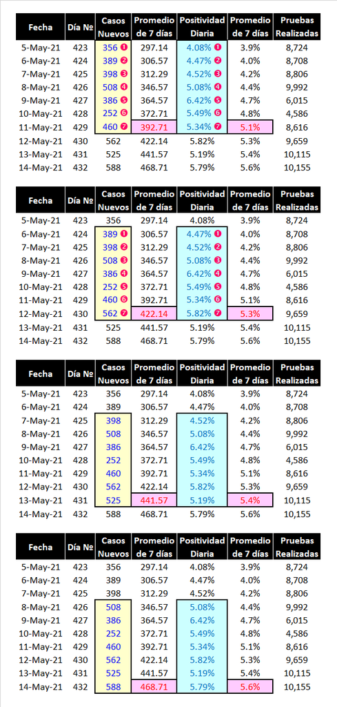

1. Las líneas de puntos rojos (azules en la gráfica UCI) representa ese promedio de 7 días, con la flecha al final de la línea demostrando la tendencia del índice. Apuntando hacia arriba, como es el caso de las gráficas de casos nuevos y positividad, propone una tendencia al alza.

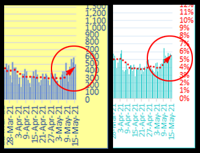

Apuntando horizontalmente, como la gráfica de hospitalizados en sala, propone una estabilización ('plateauing' en inglés) del índice. Las cifras actuales de hospitalizaciones, como puede apreciarse, todavía no reflejan el aumento reciente de casos que, según entiendo, tomarán un par de semanas en alcanzar estados críticos que requieran hospitalización.

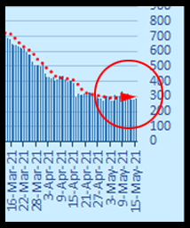

El aumento reciente de casos vaticina un aumento de hospitalizaciones y la flecha comenzará a apuntar hacia arriba.

### Sobre los ejes.

1. La razón que no aparecen todas las fechas en el eje horizontal, o todas las medidas en el eje vertical, es porque no caben en el espacio disponible. En el caso de las fechas, ha sido necesario presentar en la gráfica la fecha en intervalos de 5 para que no se amontonen una encima de la otra, como lo demuestra la siguiente imagen:

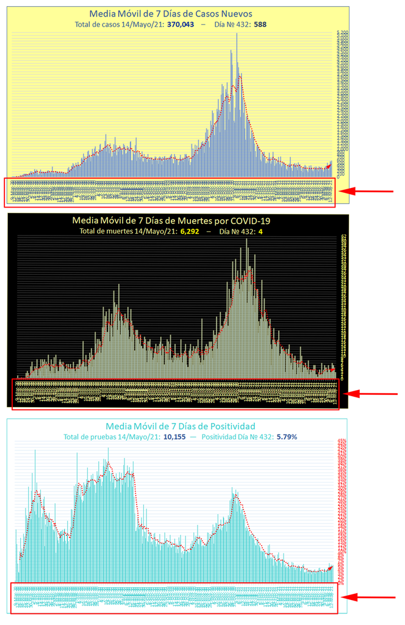

En algún momento, las fechas comenzarán a unirse nuevamente y tendré que aumentar el intervalo a 6 días (y así sucesivamente). Importante notar que a persar de no aparecer en el eje, las cifras de esos días Excel los está tomando en cuenta en la preparación de la gráfica.

El caso del eje vertical es similar. Incluir todas las unidades produciría el mismo efecto de aglomeración, complicando la toma de medidas:

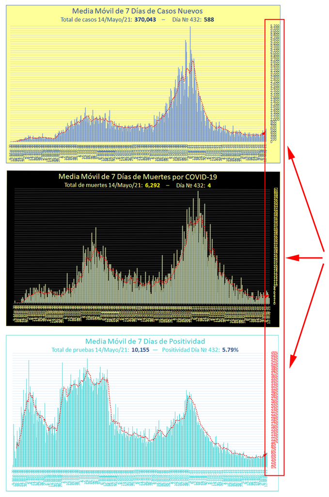

Para no poner intervalos en las unidades del eje vertical (que complicaría la toma de medida de ese índice), decidí truncar información vieja limitando la unidad máxima que se presenta. De esa manera, la flecha roja indicadora del promedio de ese día apunta a una medida más clara.

### Para cerrar.

Todo lo presentado en este documento lo aprendí durante los 14 meses que llevo observando las cifras, actualizando mis tablas, y poniendo atención diaria a noticias de canales serios como CNN y MSNBC. El canal Fox ha terminado siendo una fuente de desinformación, algunas veces presentando en programas como el de Tucker Carlson o Sean Hannity, claras mentiras.

Por último, te adelanto que puedes reproducir en cualquier medio la información que presento si la consideras apropiada.

Saludos cordiales,

**Jorge Arrocha**